# Project proposal

Y&J Code Craze

```r
library(tidyverse)
library(broom)

Internship_Data_Untidy <- read.csv("/cloud/project/data/Internship_Data_Untidy.csv")
```

## 1. Introduction

Our data comes from information compiled by Jeffry Neuhouser and their work study students about the internships that COA students have taken over the last 50 years. The data was collected by looking over old internship reports and compiling them into a spreadsheet. This dataset is still growing as Jeffry continues to go through old documents. The currently expanding nature of the body of data means that our dataset contains data only from students whose last names begin with the letters A through M. We don’t have information for students with surnames from N through Z. Each observation in this dataset represents information from a student’s internship report. Some alumni information was mistakenly added to the dataset, so we will have to filter those observations out (those rows have NAs entered under almost every column). Our variables include: the term, the year, the employer or internship site, the title of position, the location, the coordinates, and notes on the internship and location. Jeffry sent us an additional list of industries COA alumni are presently involved in. The Career Development Office has asked that we try to categorize internship data by those industries.

Based on our discussions with Jeffry and our own personal interest in the data we arrived at the following research question :

**What change in trends can be observed in COA internship data in relation to internship location and industry from 1970-2023?**

We hope that this research question can allow us to meaningfully investigate the trends across time, allowing us to explore a unique dimension in our dataset (temporal variation). We also hope that this question will address the needs of the Career Development Office by looking at where and in what field COA internships are occurring.

## 2. Data

This is a small overview of our dataset.

```r
glimpse(Internship_Data_Untidy, na.rm = TRUE)
```

```
## Rows: 1,649
## Columns: 9
## $ Term                  <chr> "Summer", "Spring", "Fall", "Fall", "Spring", "S…
## $ Year                  <chr> "2015", "2015", "2011", "2017", "1997", "2009", …
## $ Internship.Site       <chr> "Zocalo Permaculture Center", "Zocab Permacultur…
## $ Title..if.applicable. <chr> "Intern", "Assistant Manager", "Designer", "Vete…
## $ Location              <chr> "Gouldsboro, Maine", "Gouldsboro, Maine", "Solot…
## $ Latitude              <dbl> 44.478412, NA, 47.318740, -6.201808, 44.387638, …
## $ Longitude             <dbl> -68.038339, NA, 7.669828, 39.193376, -68.204336,…
## $ Notes..if.any.        <chr> "", "", "", "", "", "", "", "", "", "", "Not cle…
## $ Notes.on.Location     <chr> "", "", "", "", "", "", "", "", "coordinates for…
```

```r
#"na.rm = TRUE" is being used because our raw dataset has a lot of NA rows that we were instructed by our data source (Jeffry Neuhouser) to disregard. The data will be tidied and sorted further into the project
```

## 3. Data analysis plan

**What variables will you visualize to explore your research questions?**

We want to explore the locations in which COA students undertake internships—locally, nationally, or internationally—and if students have changed where they take internships over time. Additionally, Jeffry asked us to explore the wider regions (or as they described it , “hubs”) where students go for internships. We hope to visualize this area based distribution with something like a heat map. Upon Jeffry’s request, we will also try to visualize which terms students participate in internships. Furthermore, we want to look at the industries COA students take internships in and if there are any popular internship locations/opportunities. One idea for how to visualize this may be by using a histogram.

**Will there be any other data that you need to find to help with your research question?**

Currently we don’t need any other data to answer our research question. If we do need help, we will contact Jeffry or Rūdy (he has been doing a lot of work on compiling the data).

**Very preliminary exploratory data analysis, including some summary statistics and visualizations, along with some explanation on how they help you learn more about your data.**

Here are two initial visualizations to help us visualize what portion of students take internships in Bar Harbor versus other locations. The second graph helps us visualize the relationship between local and not local internships and the terms that students take them in.

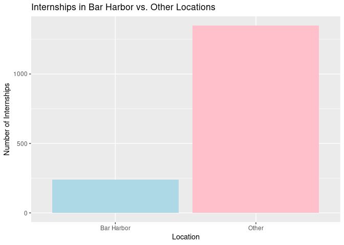

```r
Internship_BH_or_Not <- Internship_Data_Untidy %>%
mutate(BH_Location = if_else(Location == "Bar Harbor, Maine", "Bar Harbor", "Other")) %>%
filter(BH_Location != "NA")
Internship_BH_or_Not %>%
ggplot(mapping = aes(x = BH_Location,
                    fill = BH_Location)) +
geom_bar() +
labs(title = "Internships in Bar Harbor vs. Other Locations",
     x = "Location",
     y = "Number of Internships") +
scale_fill_manual(values = c("Bar Harbor" = "lightblue", "Other" = "pink")) +
guides(fill = FALSE)
```

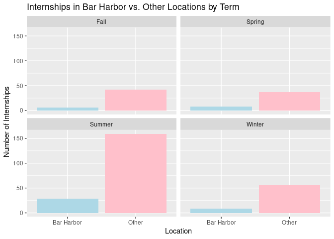

```r
Internship_BH_or_Not %>%
filter(BH_Location != "NA") %>%
filter(Term == c("Fall", "Winter", "Spring", "Summer")) %>%
ggplot(mapping = aes(x = BH_Location,
                    fill = BH_Location)) +
geom_bar() +
facet_wrap(~ Term) +
labs(title = "Internships in Bar Harbor vs. Other Locations by Term",
     x = "Location",
     y = "Number of Internships") +
scale_fill_manual(values = c("Bar Harbor" = "lightblue", "Other" = "pink")) +
guides(fill = FALSE)
```

**The data visualization(s) that you believe will be useful in exploring your question(s).**

We think that bar graphs, ridge plots, violin plots, and density graphs may be helpful to visualize our data. The majority of our data is categorical, so those visualizations will be the most helpful. We also think it could be interesting to create a map with dots or circles to represent where COA students take internships. This may be challenging, so we’ll see how it goes.

## 4. Data Ethics Review

The data ethics review section will be introduced in a separate class and is not part of the original proposal deadline.